# Pobieranie danych z Internetu

Przemysław Biecek

R i Duże Dane

# Intro

Duże dane najczęściej są generowane strumieniowo, przykładowo:

- wielkie maszyny w kopalniach z setkami czujników, monitorujących ich działanie (predictive maintenance),
- monitoring transakcji bankowych (fraud detection),
- dane z serwisów społecznościowych,
- logi ruchu sieciowego,
- scapping stron internetowych,
- i wiele innych.

# Intro

Dostęp do tych danych jest możliwy na różne sposoby, trzy najczęstsze to:

- dostęp do plików tekstowych lub bazy danych z danymi,
- dostęp zapewniony przez dostawcę danych: API (Application Programming Onterface), często typu REST (Representational State Transfer),
- zbieranie skrawków danych na własną rękę, jeżeli dane są publicznie dostępne ale nie są w strukturze łatwej do dalszego przetwarzania.

Dziś i za tydzień omówimy przykłady obu sposobów na pozyskanie danych.

# Bezpośrednie odczytanie danych z Internetu

Dane są dostępne w Internecie w strukturze tabelarycznej nie wymagającej dalszego przetwarzania.

```r
# Ranking uczelni według Polityki
dane <- read.table("http://tofesi.mimuw.edu.pl/~cogito/smarterpoland/rankingUczelni2011/RankingUczelni2011.csv",
                   sep=";", skip=1, header=TRUE)
head(dane)
```

```
##     Miasto                 Typ.Uczelni                     Reszta.Nazwy
## 1 Warszawa                 Uniwersytet                       Warszawski
## 2   Krakow                 Uniwersytet                     Jagiellonski
## 3 Warszawa                Politechnika                       Warszawska
## 4   Poznan                 Uniwersytet im. Adama Mickiewicza w Poznaniu
## 5  Wroclaw                Politechnika                       Wroclawska
## 6   Krakow Akademia Gorniczo-Hutnicza                        w Krakowie
##   ranking.2011 ranking.2010 ranking.2009 ranking.2008 suma.punktow
## 1            1            1            2            2       100.00
## 2            2            2            1            1        99.71
## 3            3            4            4            5        85.52
## 4            4            3            3            4        76.38
## 5            5            5            6            7        75.91
## 6            6            7            5            8        75.35
##   preferencje.pracodawcow ocena.kadry.akademickiej uznanie.miedzynarodowe
```

[output cut: 76 more lines]

# Bezpośrednie odczytanie danych z Internetu

Dane nie mają struktury i takimi je chcemy odczytać.

```r
# http://www.gutenberg.org/ebooks/103
# http://www.gutenberg.org/cache/epub/103/pg103.txt

# W 80 dni dookoła świata
w80dni <- readLines("http://www.gutenberg.org/cache/epub/103/pg103.txt")

# Kilka pierwszych linii
head(w80dni)
# rozbicie linii na słowa
slowa <- unlist(strsplit(w80dni, split="[^A-Za-z0-9]+"))
# liczba słów i charakterystyki
length(slowa)
barplot(table(nchar(slowa)))
head(sort(table(slowa), decreasing = TRUE), 20)
```

[output not shown]

# Parsowanie strony HTML

Dane mają strukturę ale aby je wyłuskać wymaga to trochę pracy [i znajomosci wyrażeń regularnych]

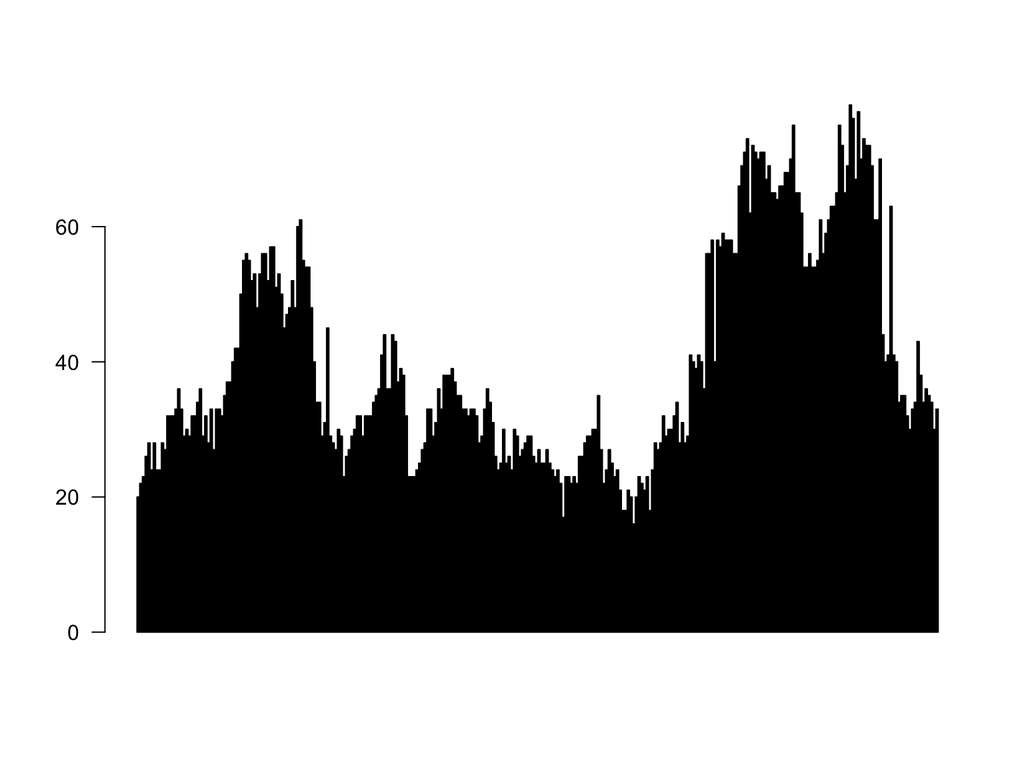

```r
# Odczytanie treści strony www
html <- readLines("https://pl.wikipedia.org/wiki/Reprezentacja_Polski_w_pi%C5%82ce_no%C5%BCnej")
html <- paste(html, collapse="")

# Wydzieramy dane łyżeczką
tmp1 <- strsplit(html, split="Rankingu FIFA")[[1]][5]
tmp2 <- strsplit(tmp1, split="najlepsze miejsce")[[1]][1]
tmp3 <- strsplit(tmp2, split="<[^>]+>")[[1]]
wartosci <- na.omit(as.numeric(tmp3))

# i rysunek pozycji reprezentajci Polski w rankingu FIFA
barplot(wartosci[wartosci < 1000], las=1, col="black")
```

# Parsowanie stroni HTML z użyciem pakietu XML

Aby nie parsować strony HTML ręcznie za każdym razem dostępnych jest wiele narzędzi, robiących parsowanie za nas.

Pakiet `XML` zawiera funkcję `readHTMLTable()` wyszukującą wszystkie tabele oraz konwertującą je do ramek danych w R.

```r
library(XML)
library(RCurl)
link <- "https://pl.wikipedia.org/wiki/Lista_mecz%C3%B3w_reprezentacji_Polski_w_pi%C5%82ce_no%C5%BCnej"
xData <- getURL(link)
tabele <- readHTMLTable(xData, stringsAsFactors = FALSE)
length(tabele)
```

```
## [1] 9
```

```r
statystyki <- tabele[[1]]
head(statystyki)
```

```
##    Lp.  Data         Miejsce  Gospodarz    –    Gość     Wynik
## 1 2001  <NA>            <NA>       <NA> <NA>    <NA>      <NA>
## 2 594. 28.02 *Larnaka (Cypr) Szwajcaria    –  Polska 0:4 (0:2)
## 3 595. 24.03            Oslo   Norwegia    –  Polska 2:3 (0:2)
## 4 596. 28.03        Warszawa     Polska    – Armenia 4:0 (2:0)
## 5 597. 25.04       Bydgoszcz     Polska    – Szkocja 1:1 (0:0)
## 6 598. 02.06         Cardiff      Walia    –  Polska 1:2 (1:1)
##                                                           Bramki dla Polski
## 1                                                                      <NA>
## 2         Emmanuel Olisadebe, Bartosz Karwan, Tomasz Hajto, Jacek Krzynówek
## 3                                 eMŚ, Emmanuel Olisadebe 2, Bartosz Karwan
## 4 eMŚ, Michał Żewłakow, Emmanuel Olisadebe, Marcin Żewłakow, Bartosz Karwan
## 5                                                          Radosław Kałużny
## 6                               eMŚ, Emmanuel Olisadebe, Paweł Kryszałowicz
```

# Parsowanie stroni HTML z pakietem rvest

Jeżeli dane nie są w postaci tabelarycznej, bardzo wygodną biblioteką do pracy z danymi jest `rvest`.

Użyteczne funkcje:

- html - tworzy strukturę drzewiastą html
- html_nodes - wyszukuje węzły w drzewie pasujące do określonego wzorca
- html_text, html_tag, html_attrs - wyciąga treść lub atrybuty węzłów html.

```r
library(rvest)
gazeta <- read_html("http://gazeta.pl")
cast <- html_nodes(gazeta, "a")
head(html_text(cast))
```

```
## [1] ""           "gazeta.pl"  "Wiadomo¶ci" "Sport"      "Biznes"
## [6] "Kobieta"
```

```r
head(html_attr(cast, "href"))
```

```
## [1] "http://serwisy.gazeta.pl/O_nas/1,111259,8856779,Ochrona_prywatnosci.html"
## [2] "http://www.gazeta.pl/0,0.html"
## [3] "http://wiadomosci.gazeta.pl/wiadomosci/0,0.html"
## [4] "http://www.sport.pl/sport-hp/0,0.html"
## [5] "http://pieniadze.gazeta.pl/pieniadz/0,0.html"
## [6] "http://kobieta.gazeta.pl/kobieta/0,0.html"
```

# Jak znajdować uchwyty CSS

Używając gadgetSeelctor można łatwo określić ścieżkę wyszukiwania w drzewie html.

```r
oskary <- html("http://www.filmweb.pl/oscary")
filmy <- html_nodes(oskary, ".title")
html_text(filmy)
```

```
## character(0)
```

Pakiet `rvest` pozwala też na parsowanie tabel oraz na obsługę formularzy, sesji i śledzenie linków.

```r
lego_movie <- html("http://www.imdb.com/title/tt1490017/")

htab <- html_nodes(lego_movie, "table")[[3]]
html_table(htab)
```

```
##                                                      X1
## 1                                     Amazon Affiliates
## 2 Amazon Video\n                Watch Movies &TV Online
##                                                               X2
## 1                                                           <NA>
## 2 Prime Video\n                Unlimited Streamingof Movies & TV
##                                                           X3
## 1                                                       <NA>
## 2 Amazon Germany\n                Buy Movies onDVD & Blu-ray
##                                                         X4
## 1                                                     <NA>
## 2 Amazon Italy\n                Buy Movies onDVD & Blu-ray
##                                                          X5
## 1                                                      <NA>
## 2 Amazon France\n                Buy Movies onDVD & Blu-ray
##                                                        X6
## 1                                                    <NA>
## 2 Amazon India\n                Buy Movie andTV Show DVDs
##                                             X7
## 1                                         <NA>
## 2 DPReview\n                DigitalPhotography
##                                             X8
## 1                                         <NA>
## 2 Audible\n                DownloadAudio Books
```

# API bez autoryzacji

Fundacja MojePanstwo udostępnia API dzieki któremu można automatycznie pobrać dane w formacie JSON. Opis API jest na stronie https://mojepanstwo.pl/api

Między innymi udostępnia kopię Banku Danych Lokalnych. Poleceniem `search` można wyszukiwać tabele z odpowiednimi danymi.

Między innymi udostępnia dane kandydatów do Sejmu. Poleceniem `https://api-v3.mojepanstwo.pl/dane/poslowie` pobrać listę posłów.

```r
url <- 'https://api-v3.mojepanstwo.pl/dane/poslowie?limit=500'
document <- rjson::fromJSON(file=url, method='C')

ludzie <- sapply(document[[1]], function(x) x$data$ludzie.nazwa)
kluby <- sapply(document[[1]], function(x) x$data$sejm_kluby.nazwa)
urodzenie <- sapply(document[[1]], function(x) x$data$poslowie.data_urodzenia)
glosy <- sapply(document[[1]], function(x) x$data$poslowie.liczba_glosow)
head(data.frame(ludzie, kluby, urodzenie, glosy))
```

```
##             ludzie                  kluby  urodzenie glosy
## 1      Łukasz Tusk  Platforma Obywatelska 1985-09-24  8620
## 2     Andrzej Dera    Zjednoczona Prawica 1961-09-10 17606
## 3 Piotr Paweł Bauć          Ruch Palikota 1960-06-29 13392
## 4  Rafał Grupiński  Platforma Obywatelska 1952-09-26 40510
## 5   Grzegorz Długi               Kukiz'15 1955-06-16     0
## 6   Leszek Galemba Prawo i Sprawiedliwość 1966-03-07     0
```